# Null simulation study of EBMF programs

This vignette evaluates empirical Bayes matrix factorisation (EBMF) programs against **pure-null** synthetic data: `K = 0`, so no modules, driver SNPs, or driver traits are ever planted. Each simulation is generated by `simulate_trait()` with only the target-trait row plus unstructured background traits. The pipeline — `run_univariate_clustering()` followed by `summarise_ebmf_programs()` — is byte-for-byte the same battery used in the module simulations (`investigation-univariate-simulations.html`); the analysis settings are also identical. The only difference is that EBMF is now trying to discover programs in data where the only structure is randomness.

The checks are exactly the same as on the real pipeline:

Under a true null, **any** program of high or medium confidence is a false discovery, so the tier shares below are false-discovery rates: they show how often each tier (and the pipeline as a whole) is fooled by random background. `background_absorbed` is the SNP-level analogue — the fraction of background SNPs pulled into valid programs.

The `single_trait` share has its own reading. Null programs almost always rest on one trait, so when the trait count was checked first they were all labelled `single_trait`. Now a null program is `single_trait` only if its SNPs also pass the similarity test. The `single_trait` share is therefore how often noise produces a program that lands in the “needs a closer look” tier rather than in `low`, where it can be discarded.

Because `K = 0`, the module-only generative parameters (`module_sizes`, `overlap`, `n_traits_per_module`, `trait_overlap`, `driver_sharing`, `p_structural_zero`, `p_spurious`, `effect_tail`) are inert and are not exposed here. The active axes of background realism are `p_active_background` (how often a background trait is observed at a SNP), `background_sparsity_sd` (heavy-tailed per-trait density variation), `background_effect_scale` (background magnitude relative to `effect_size`), and `noise_sd` (per-cell noise). Each version below holds everything else at its realistic baseline and varies one axis.

## Does this simulation exercise the gates in the regime real data uses them?

The validation gates act on the SNP similarity graph, so what matters is not whether the simulated matrix has realistic per-trait sparsity and magnitude marginals – it is whether the *graph* those marginals induce resembles a real one. Those are not the same thing, and matching the marginals is not sufficient.

`simulated_graph_diagnostics()` measures the simulated graph and `real_bmi_graph_targets()` carries the values measured on the BMI pleiotropy matrix. The row to read first is `random_set_pass_rate`: the fraction of random SNP sets whose mean internal similarity clears 0.3. On real BMI data that is about 0.94 – a random set of SNPs passes the old absolute gate almost always, which is why that gate carried no specificity. Where the simulated value is near 0, a random set can never pass, so a null simulation study **cannot detect an uninformative gate** and its false-discovery rate is close to un-failable by construction.

The two generative parameters that move this are `background_corr` (background traits sharing structure, so they contribute to SNP-SNP similarity at all – at `0` they are independent and random-signed and contribute nothing) and `snp_pleiotropy_sd` (per-SNP heterogeneity in how many traits a SNP is observed on, which is what brings the median pairwise overlap down towards the real ~3 and produces the sparse SNPs that carry high cosines).

```
#>
#>
#> Table: Similarity-graph diagnostics for this run's generative settings against the values measured on the real BMI pleiotropy matrix. Read random_set_pass_rate first: where it is near 0 the gates are not being tested in the regime real data puts them in, whatever the recovery metrics below say.
#>
#> |statistic                 | simulated| real_bmi|
#> |:-------------------------|---------:|--------:|
#> |density                   |  0.110000|   0.0198|
#> |median_pair_overlap       |  3.000000|   3.0000|
#> |frac_pairs_zero_overlap   |  0.000000|   0.2140|
#> |mean_similarity           |  0.007420|   0.3480|
#> |median_similarity         |  0.005700|   0.3230|
#> |mean_similarity_no_target | -0.000324|   0.2840|
#> |random_set_mean_internal  |  0.007580|   0.3480|
#> |random_set_pass_rate      |  0.000000|   0.9350|
```

## Simulation design (ADEMP)

This null study follows the ADEMP structure of Morris, White and Crowther (2019, *Statistics in Medicine* 38:2074-2102, ); it is the testing-target companion to `investigation-univariate-simulations.html`.

**Aims.** To estimate the **type I error / false-discovery rate** of the EBMF program pipeline under a true null, and how that rate depends on background realism. This is a *stretch-or-break* aim: find where the gates are fooled.

**Data-generating mechanism.** `simulate_trait()` with `K = 0`, so only the oriented target row and unstructured background rows exist. The varied factors are `p_active_background`, `background_sparsity_sd`, `background_effect_scale`, and `noise_sd`, each varied one at a time from the realistic baseline.

**Estimand / target.** The target is the null hypothesis of no planted module; under it, any program passing all four gates is a false discovery, so the `valid` rate is the pipeline-level false-discovery rate.

**Methods.** Byte-for-byte the same pipeline and thresholds as the module study: `run_univariate_clustering()` then `summarise_ebmf_programs()`, which drops programs below `min_module_size` and gives the rest a confidence tier (similarity test, then effective number of traits, then connectedness), with factor strength and replication reported.

**Performance measures.**

- `n programs`: EBMF programs surviving the lFSR/magnitude membership gate.
- `valid programs`: programs of high or medium confidence.
- `valid rate = valid programs / n programs` (program-level false-discovery rate).
- `background_absorbed = |{background SNPs in valid programs}| / n_background` (SNP-level false-discovery rate).
- Tier rates: the share of programs in each confidence tier (`high`, `medium`, `single_trait`, `low`). `single_trait` counts programs that pass the similarity test but rest on one trait: noise that needs a closer look rather than being discarded.

**Monte Carlo uncertainty.** Each rate is the mean over `n_sim` replicates (default 3; override with `params = list(n_sim = ...)` for fast test runs), with the replicate as the Monte Carlo unit. Proportions carry MC SE `sqrt(p(1-p)/n_sim)` and a 95% Monte Carlo interval; continuous measures carry `sd / sqrt(n_sim)`. Common random numbers are used across null versions, and the per-replicate seed is recorded in the estimates dataset.

Fixed EBMF analysis and validation settings (identical across all null versions)

|  | parameter | value |
| --- | --- | --- |
| trait_subset | trait_subset | phenotypic |
| min_snp_signals | min_snp_signals | 2 |
| min_module_size | min_module_size | 3 |
| compress_method | compress_method | asinh |
| compress_scale | compress_scale | 5 |
| similarity_threshold | similarity_threshold | 0.5 |
| ebmf_lfsr_threshold | ebmf_lfsr_threshold | 0.02 |
| ebmf_magnitude_threshold | ebmf_magnitude_threshold | 0.75 |
| ebmf_drop_global | ebmf_drop_global | TRUE |
| ebmf_prior | ebmf_prior | point_laplace |
| ebmf_backfit | ebmf_backfit | TRUE |
| min_mean_internal | min_mean_internal | 0.3 |
| min_connectedness | min_connectedness | 0.25 |
| n_null | n_null | 1 |
| alpha_membership | alpha_membership | 0.05 |
| n_candidate_tier | n_candidate_tier | 25 |
| n_stability_rep | n_stability_rep | 0 |
| frac_traits | frac_traits | 0.8 |
| stability_top_n | stability_top_n | 20 |
| posterior_stat | posterior_stat | median |
| posterior_evidence_cap | posterior_evidence_cap | 50 |
| redundancy_threshold | redundancy_threshold | 0.9 |
| cores | cores | 5 |
| n_sim | n_sim | 3 |

## Null versions

Every version plants no modules (`K = 0`); the versions differ only in the background realism parameter being stressed, with everything else at its realistic baseline.

Generative parameters for each null version (all versions plant no modules, K = 0)

| version | K | n_snps | n_traits | noise_sd | effect_size | p_active_background | background_sparsity_sd | background_effect_scale | target_pattern |
| --- | --- | --- | --- | --- | --- | --- | --- | --- | --- |
| baseline (default background) | 0 | 300 | 100 | 1 | 6 | 0.1 | 1.2 | 0.5 | module |
| dense background (p_active_background = 0.3) | 0 | 300 | 100 | 1 | 6 | 0.3 | 1.2 | 0.5 | module |
| strong background magnitudes (background_effect_scale = 1.5) | 0 | 300 | 100 | 1 | 6 | 0.1 | 1.2 | 1.5 | module |
| high noise (noise_sd = 4) | 0 | 300 | 100 | 4 | 6 | 0.1 | 1.2 | 0.5 | module |

## Aggregate results

Across all replicates and programs of each version, the tables below report the number of programs EBMF produced before validation (`n programs`), how many survived every check (`valid programs`), the false-discovery rates (`valid rate` at program level, `background absorbed` at SNP level), and the per-gate pass rates. Estimates are averages over 3 replicates and carry a **Monte Carlo standard error** in parentheses (ADEMP; Morris, White & Crowther 2019): the replicate is the Monte Carlo unit, so every number is an estimate with quantified uncertainty.

Null-version false-discovery output (mean across 3 replicates; Monte Carlo SE in parentheses). Under a true null, valid programs are false discoveries and background absorbed is the SNP-level false-discovery rate.

| tier | n programs | valid programs | background absorbed |
| --- | --- | --- | --- |
| baseline (default background) | 33.67 (3.38) | 0.00 (0.00) | 0.00 (0.00) |
| dense background (p_active_background = 0.3) | 48.00 (2.65) | 0.00 (0.00) | 0.00 (0.00) |
| high noise (noise_sd = 4) | 39.33 (3.18) | 0.00 (0.00) | 0.00 (0.00) |
| strong background magnitudes (background_effect_scale = 1.5) | 62.33 (5.78) | 0.00 (0.00) | 0.00 (0.00) |

Per-gate pass rates by null version (percent; per-replicate rate averaged across 3 replicates, Monte Carlo SE in parentheses). The high / medium / single trait / low are the confidence-tier shares; valid = high or medium.

| tier | high | medium | single trait | low | valid |
| --- | --- | --- | --- | --- | --- |
| baseline (default background) | 0.00 (0.00) | 0.00 (0.00) | 12.88 (19.34) | 87.12 (19.34) | 0.00 (0.00) |
| dense background (p_active_background = 0.3) | 0.00 (0.00) | 0.00 (0.00) | 6.67 (14.41) | 93.33 (14.41) | 0.00 (0.00) |
| high noise (noise_sd = 4) | 0.00 (0.00) | 0.00 (0.00) | 14.62 (20.40) | 85.38 (20.40) | 0.00 (0.00) |
| strong background magnitudes (background_effect_scale = 1.5) | 0.00 (0.00) | 0.00 (0.00) | 2.39 (8.81) | 97.61 (8.81) | 0.00 (0.00) |

`high`, `medium`, `single trait` and `low` are the shares of programs in each confidence tier; `valid` is high plus medium. Under the null, `single trait` is the share of noise programs that pass the similarity test on one trait’s hits; the rest that fail the test are `low`.

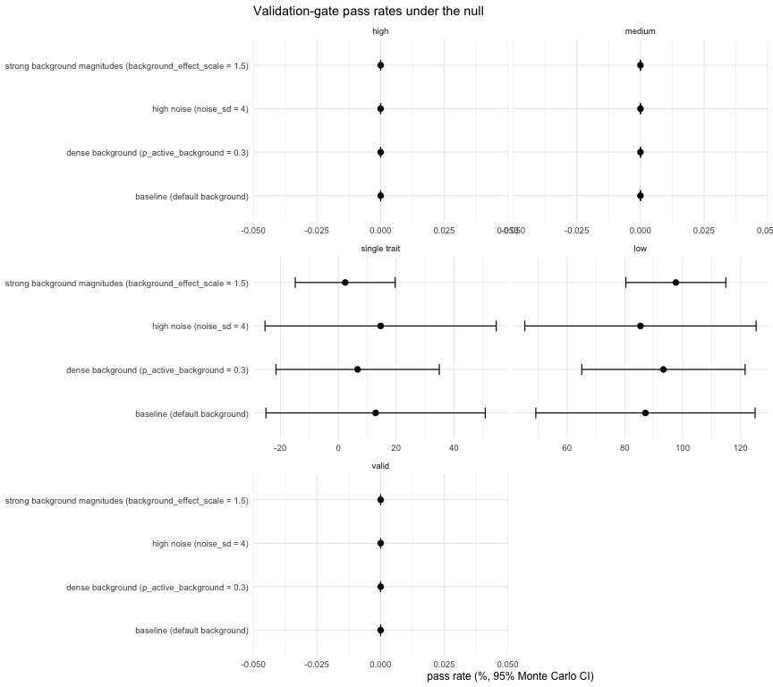

## Program-level validation checks

For each version, every program found across the replicates is listed by replicate and then by confidence tier (green high, orange medium, grey single trait, red low).

### baseline (default background)

| rep | program | confidence | n_snps | n_snps filtered | effective traits | mean internal similarity | excess similarity | similarity q | connectedness | excess connectedness | factor PVE % | replication |
| --- | --- | --- | --- | --- | --- | --- | --- | --- | --- | --- | --- | --- |
| 1 | 22 | single_trait | 300 | 4 | 1.00 | 0.382 | 0.381 | 0.0110 | 0.167 | 0.154 | 0.50 | NA |
| 1 | 3 | single_trait | 300 | 17 | 1.00 | 0.069 | 0.067 | 0.0240 | 0.221 | 0.208 | 2.72 | NA |
| 1 | 1 | single_trait | 300 | 23 | 1.00 | 0.045 | 0.044 | 0.0250 | 0.292 | 0.279 | 4.64 | NA |
| 1 | 7 | single_trait | 300 | 13 | 1.00 | 0.078 | 0.077 | 0.0250 | 0.244 | 0.230 | 1.23 | NA |
| 1 | 24 | low | 300 | 6 | 1.00 | 0.113 | 0.111 | 0.1100 | 0.067 | 0.054 | 0.51 | NA |
| 1 | 14 | low | 300 | 12 | 1.00 | 0.053 | 0.052 | 0.1200 | 0.045 | 0.032 | 1.16 | NA |
| 1 | 17 | low | 300 | 9 | 1.00 | 0.040 | 0.039 | 0.4000 | 0.111 | 0.098 | 0.79 | NA |
| 1 | 8 | low | 300 | 13 | 1.00 | 0.020 | 0.019 | 0.5600 | 0.128 | 0.115 | 1.18 | NA |
| 1 | 15 | low | 300 | 7 | 1.08 | 0.035 | 0.033 | 0.5600 | 0.095 | 0.082 | 0.82 | NA |
| 1 | 10 | low | 300 | 12 | 1.02 | 0.009 | 0.008 | 0.8400 | 0.121 | 0.108 | 1.34 | NA |
| 1 | 18 | low | 300 | 8 | 1.00 | -0.016 | -0.017 | 0.9900 | 0.036 | 0.023 | 0.88 | NA |
| 1 | 19 | low | 300 | 8 | 1.00 | -0.016 | -0.017 | 0.9900 | 0.000 | -0.013 | 0.68 | NA |
| 1 | 12 | low | 300 | 10 | 1.00 | -0.017 | -0.019 | 0.9900 | 0.089 | 0.076 | 1.22 | NA |
| 1 | 16 | low | 300 | 13 | 1.00 | -0.022 | -0.023 | 0.9900 | 0.154 | 0.141 | 1.12 | NA |
| 1 | 11 | low | 300 | 14 | 1.00 | -0.020 | -0.022 | 0.9900 | 0.066 | 0.053 | 1.26 | NA |
| 1 | 2 | low | 300 | 26 | 1.00 | -0.012 | -0.013 | 0.9900 | 0.178 | 0.165 | 3.93 | NA |
| 1 | 13 | low | 300 | 10 | 1.08 | -0.034 | -0.036 | 0.9900 | 0.022 | 0.009 | 1.07 | NA |
| 1 | 4 | low | 300 | 17 | 1.00 | -0.020 | -0.021 | 0.9900 | 0.059 | 0.046 | 2.03 | NA |
| 1 | 6 | low | 300 | 12 | 1.00 | -0.029 | -0.030 | 0.9900 | 0.091 | 0.078 | 1.38 | NA |
| 1 | 21 | low | 300 | 4 | 1.02 | -0.104 | -0.106 | 0.9900 | 0.167 | 0.154 | 0.51 | NA |
| 1 | 9 | low | 300 | 12 | 1.00 | -0.032 | -0.033 | 0.9900 | 0.106 | 0.093 | 1.34 | NA |
| 1 | 23 | low | 300 | 6 | 1.00 | -0.072 | -0.074 | 0.9900 | 0.133 | 0.120 | 0.62 | NA |
| 1 | 5 | low | 300 | 16 | 1.00 | -0.029 | -0.030 | 0.9900 | 0.117 | 0.103 | 1.82 | NA |
| 1 | 25 | low | 300 | 5 | 1.00 | -0.102 | -0.103 | 0.9900 | 0.000 | -0.012 | 0.44 | NA |
| 1 | 20 | low | 300 | 9 | 1.00 | -0.058 | -0.059 | 0.9900 | 0.083 | 0.070 | 0.73 | NA |
| 1 | 27 | low | 300 | 7 | 1.00 | -0.078 | -0.080 | 0.9900 | 0.095 | 0.082 | 0.47 | NA |
| 1 | 26 | low | 300 | 6 | 1.00 | -0.093 | -0.095 | 0.9900 | 0.067 | 0.054 | 0.62 | NA |
| 2 | 15 | single_trait | 300 | 10 | 1.00 | 0.275 | 0.273 | 0.0019 | 0.022 | 0.016 | 0.72 | NA |
| 2 | 19 | single_trait | 300 | 12 | 1.00 | 0.151 | 0.149 | 0.0019 | 0.121 | 0.115 | 0.78 | NA |
| 2 | 37 | single_trait | 300 | 4 | 1.00 | 0.358 | 0.356 | 0.0028 | 0.167 | 0.161 | 0.50 | NA |

[output cut: 71 more lines]

### dense background (p_active_background = 0.3)

| rep | program | confidence | n_snps | n_snps filtered | effective traits | mean internal similarity | excess similarity | similarity q | connectedness | excess connectedness | factor PVE % | replication |
| --- | --- | --- | --- | --- | --- | --- | --- | --- | --- | --- | --- | --- |
| 1 | 10 | single_trait | 300 | 26 | 1.00 | 0.048 | 0.047 | 0.0044 | 0.018 | 0.016 | 1.79 | NA |
| 1 | 41 | single_trait | 300 | 5 | 1.00 | 0.230 | 0.229 | 0.0044 | 0.000 | -0.002 | 0.34 | NA |
| 1 | 9 | single_trait | 300 | 23 | 1.00 | 0.044 | 0.043 | 0.0059 | 0.004 | 0.002 | 2.13 | NA |
| 1 | 16 | single_trait | 300 | 16 | 1.00 | 0.058 | 0.057 | 0.0110 | 0.017 | 0.015 | 1.37 | NA |
| 1 | 17 | single_trait | 300 | 15 | 1.00 | 0.057 | 0.056 | 0.0180 | 0.029 | 0.026 | 1.09 | NA |
| 1 | 32 | single_trait | 300 | 6 | 1.13 | 0.119 | 0.118 | 0.0440 | 0.067 | 0.065 | 0.51 | NA |
| 1 | 7 | low | 300 | 16 | 1.00 | 0.032 | 0.030 | 0.1800 | 0.033 | 0.031 | 2.43 | NA |
| 1 | 1 | low | 300 | 30 | 1.00 | 0.013 | 0.012 | 0.3600 | 0.025 | 0.023 | 3.47 | NA |
| 1 | 31 | low | 300 | 5 | 1.25 | 0.074 | 0.073 | 0.3600 | 0.000 | -0.002 | 0.49 | NA |
| 1 | 38 | low | 300 | 6 | 2.55 | 0.058 | 0.057 | 0.3600 | 0.000 | -0.002 | 0.38 | NA |
| 1 | 42 | low | 300 | 4 | 1.00 | 0.077 | 0.077 | 0.4100 | 0.167 | 0.165 | 0.32 | NA |
| 1 | 14 | low | 300 | 14 | 1.00 | 0.022 | 0.020 | 0.4100 | 0.011 | 0.009 | 1.53 | NA |
| 1 | 3 | low | 300 | 27 | 1.00 | 0.011 | 0.010 | 0.4400 | 0.017 | 0.015 | 2.59 | NA |
| 1 | 13 | low | 300 | 15 | 1.00 | 0.013 | 0.011 | 0.6700 | 0.029 | 0.026 | 1.37 | NA |
| 1 | 43 | low | 300 | 4 | 1.25 | 0.027 | 0.027 | 0.9000 | 0.000 | -0.002 | 0.35 | NA |
| 1 | 28 | low | 300 | 10 | 1.00 | 0.009 | 0.008 | 0.9300 | 0.000 | -0.002 | 0.65 | NA |
| 1 | 34 | low | 300 | 9 | 1.00 | 0.004 | 0.003 | 1.0000 | 0.028 | 0.026 | 0.49 | NA |
| 1 | 2 | low | 300 | 30 | 1.00 | 0.001 | 0.000 | 1.0000 | 0.021 | 0.019 | 3.24 | NA |
| 1 | 8 | low | 300 | 17 | 1.00 | -0.001 | -0.002 | 1.0000 | 0.015 | 0.013 | 1.95 | NA |
| 1 | 22 | low | 300 | 14 | 1.00 | -0.005 | -0.007 | 1.0000 | 0.000 | -0.002 | 0.80 | NA |
| 1 | 24 | low | 300 | 11 | 1.12 | -0.008 | -0.009 | 1.0000 | 0.036 | 0.034 | 0.64 | NA |
| 1 | 26 | low | 300 | 11 | 1.00 | -0.008 | -0.010 | 1.0000 | 0.018 | 0.016 | 0.75 | NA |
| 1 | 29 | low | 300 | 10 | 1.00 | -0.010 | -0.012 | 1.0000 | 0.022 | 0.020 | 0.69 | NA |
| 1 | 19 | low | 300 | 16 | 1.00 | -0.006 | -0.007 | 1.0000 | 0.017 | 0.015 | 1.12 | NA |
| 1 | 37 | low | 300 | 5 | 1.00 | -0.024 | -0.025 | 1.0000 | 0.100 | 0.098 | 0.46 | NA |
| 1 | 12 | low | 300 | 17 | 1.00 | -0.007 | -0.008 | 1.0000 | 0.007 | 0.005 | 1.48 | NA |
| 1 | 35 | low | 300 | 8 | 1.00 | -0.017 | -0.019 | 1.0000 | 0.000 | -0.002 | 0.56 | NA |
| 1 | 39 | low | 300 | 8 | 1.00 | -0.017 | -0.019 | 1.0000 | 0.000 | -0.002 | 0.43 | NA |
| 1 | 15 | low | 300 | 12 | 1.00 | -0.011 | -0.013 | 1.0000 | 0.000 | -0.002 | 1.36 | NA |
| 1 | 33 | low | 300 | 8 | 1.00 | -0.019 | -0.020 | 1.0000 | 0.000 | -0.002 | 0.61 | NA |

[output cut: 114 more lines]

### strong background magnitudes (background_effect_scale = 1.5)

| rep | program | confidence | n_snps | n_snps filtered | effective traits | mean internal similarity | excess similarity | similarity q | connectedness | excess connectedness | factor PVE % | replication |
| --- | --- | --- | --- | --- | --- | --- | --- | --- | --- | --- | --- | --- |
| 1 | 15 | single_trait | 300 | 26 | 1.00 | 0.057 | 0.056 | 0.0052 | 0.065 | 0.056 | 1.91 | NA |
| 1 | 1 | single_trait | 300 | 58 | 1.00 | 0.026 | 0.025 | 0.0052 | 0.065 | 0.057 | 7.44 | NA |
| 1 | 31 | single_trait | 300 | 11 | 1.02 | 0.113 | 0.112 | 0.0170 | 0.036 | 0.028 | 0.81 | NA |
| 1 | 7 | low | 300 | 32 | 1.00 | 0.030 | 0.029 | 0.0690 | 0.018 | 0.010 | 2.15 | NA |
| 1 | 3 | low | 300 | 41 | 1.00 | 0.020 | 0.019 | 0.1300 | 0.030 | 0.022 | 4.11 | NA |
| 1 | 23 | low | 300 | 21 | 1.00 | 0.031 | 0.030 | 0.2100 | 0.019 | 0.011 | 1.17 | NA |
| 1 | 52 | low | 300 | 3 | 1.00 | 0.166 | 0.165 | 0.4700 | 0.000 | -0.008 | 0.33 | NA |
| 1 | 2 | low | 300 | 58 | 1.00 | 0.007 | 0.006 | 0.6800 | 0.049 | 0.041 | 6.32 | NA |
| 1 | 53 | low | 300 | 4 | 1.27 | 0.080 | 0.080 | 0.7600 | 0.000 | -0.009 | 0.39 | NA |
| 1 | 37 | low | 300 | 9 | 1.00 | 0.026 | 0.025 | 0.9800 | 0.000 | -0.008 | 0.59 | NA |
| 1 | 39 | low | 300 | 8 | 1.09 | 0.023 | 0.022 | 1.0000 | 0.036 | 0.028 | 0.47 | NA |
| 1 | 17 | low | 300 | 15 | 1.00 | 0.011 | 0.009 | 1.0000 | 0.019 | 0.011 | 1.22 | NA |
| 1 | 26 | low | 300 | 13 | 1.00 | 0.010 | 0.008 | 1.0000 | 0.026 | 0.017 | 0.88 | NA |
| 1 | 28 | low | 300 | 15 | 1.00 | 0.006 | 0.005 | 1.0000 | 0.010 | 0.001 | 0.94 | NA |
| 1 | 29 | low | 300 | 9 | 1.08 | 0.007 | 0.006 | 1.0000 | 0.083 | 0.075 | 0.83 | NA |
| 1 | 10 | low | 300 | 25 | 1.00 | 0.003 | 0.002 | 1.0000 | 0.043 | 0.035 | 1.96 | NA |
| 1 | 34 | low | 300 | 11 | 1.00 | 0.004 | 0.003 | 1.0000 | 0.000 | -0.008 | 0.71 | NA |
| 1 | 40 | low | 300 | 8 | 1.01 | 0.004 | 0.003 | 1.0000 | 0.036 | 0.028 | 0.54 | NA |
| 1 | 48 | low | 300 | 8 | 1.00 | -0.002 | -0.003 | 1.0000 | 0.000 | -0.008 | 0.44 | NA |
| 1 | 32 | low | 300 | 15 | 1.00 | -0.001 | -0.002 | 1.0000 | 0.010 | 0.001 | 0.65 | NA |
| 1 | 11 | low | 300 | 32 | 1.00 | 0.000 | -0.001 | 1.0000 | 0.016 | 0.008 | 2.18 | NA |
| 1 | 5 | low | 300 | 40 | 1.00 | 0.000 | -0.001 | 1.0000 | 0.031 | 0.022 | 3.64 | NA |
| 1 | 35 | low | 300 | 14 | 1.00 | -0.003 | -0.005 | 1.0000 | 0.011 | 0.003 | 0.73 | NA |
| 1 | 44 | low | 300 | 8 | 1.00 | -0.010 | -0.011 | 1.0000 | 0.000 | -0.008 | 0.45 | NA |
| 1 | 27 | low | 300 | 15 | 1.00 | -0.005 | -0.006 | 1.0000 | 0.000 | -0.008 | 1.01 | NA |
| 1 | 9 | low | 300 | 26 | 1.00 | -0.002 | -0.003 | 1.0000 | 0.034 | 0.026 | 1.97 | NA |
| 1 | 21 | low | 300 | 27 | 1.00 | -0.002 | -0.004 | 1.0000 | 0.014 | 0.006 | 1.50 | NA |
| 1 | 18 | low | 300 | 29 | 1.00 | -0.002 | -0.003 | 1.0000 | 0.015 | 0.007 | 1.69 | NA |
| 1 | 14 | low | 300 | 29 | 1.00 | -0.003 | -0.004 | 1.0000 | 0.005 | -0.003 | 1.75 | NA |
| 1 | 20 | low | 300 | 21 | 1.00 | -0.006 | -0.007 | 1.0000 | 0.024 | 0.016 | 1.25 | NA |

[output cut: 157 more lines]

### high noise (noise_sd = 4)

| rep | program | confidence | n_snps | n_snps filtered | effective traits | mean internal similarity | excess similarity | similarity q | connectedness | excess connectedness | factor PVE % | replication |
| --- | --- | --- | --- | --- | --- | --- | --- | --- | --- | --- | --- | --- |
| 1 | 31 | single_trait | 300 | 5 | 1.00 | 0.490 | 0.488 | 0.0033 | 0.300 | 0.287 | 0.39 | NA |
| 1 | 24 | single_trait | 300 | 4 | 1.00 | 0.382 | 0.380 | 0.0130 | 0.167 | 0.153 | 0.46 | NA |
| 1 | 4 | single_trait | 300 | 17 | 1.00 | 0.069 | 0.068 | 0.0220 | 0.221 | 0.207 | 2.48 | NA |
| 1 | 28 | single_trait | 300 | 6 | 1.00 | 0.194 | 0.192 | 0.0220 | 0.400 | 0.387 | 0.47 | NA |
| 1 | 16 | single_trait | 300 | 13 | 1.00 | 0.078 | 0.077 | 0.0230 | 0.244 | 0.231 | 1.12 | NA |
| 1 | 2 | single_trait | 300 | 22 | 1.00 | 0.040 | 0.039 | 0.0470 | 0.320 | 0.307 | 4.23 | NA |
| 1 | 25 | low | 300 | 6 | 1.00 | 0.113 | 0.111 | 0.1100 | 0.067 | 0.053 | 0.47 | NA |
| 1 | 13 | low | 300 | 12 | 1.00 | 0.053 | 0.052 | 0.1100 | 0.045 | 0.032 | 1.05 | NA |
| 1 | 30 | low | 300 | 5 | 1.13 | 0.116 | 0.115 | 0.1300 | 0.300 | 0.287 | 0.53 | NA |
| 1 | 17 | low | 300 | 9 | 1.00 | 0.040 | 0.039 | 0.3300 | 0.111 | 0.098 | 0.72 | NA |
| 1 | 18 | low | 300 | 7 | 1.00 | 0.035 | 0.034 | 0.5000 | 0.095 | 0.082 | 0.73 | NA |
| 1 | 9 | low | 300 | 12 | 1.00 | 0.020 | 0.018 | 0.5000 | 0.152 | 0.139 | 1.08 | NA |
| 1 | 10 | low | 300 | 12 | 1.02 | 0.009 | 0.008 | 0.8200 | 0.121 | 0.108 | 1.22 | NA |
| 1 | 1 | low | 300 | 24 | 12.50 | 0.002 | 0.000 | 0.9900 | 0.004 | -0.009 | 6.70 | NA |
| 1 | 19 | low | 300 | 8 | 1.00 | -0.016 | -0.018 | 0.9900 | 0.036 | 0.023 | 0.81 | NA |
| 1 | 20 | low | 300 | 8 | 1.00 | -0.016 | -0.018 | 0.9900 | 0.000 | -0.013 | 0.62 | NA |
| 1 | 8 | low | 300 | 11 | 1.00 | -0.013 | -0.015 | 0.9900 | 0.109 | 0.096 | 1.23 | NA |
| 1 | 14 | low | 300 | 10 | 1.00 | -0.023 | -0.024 | 0.9900 | 0.022 | 0.009 | 0.93 | NA |
| 1 | 15 | low | 300 | 13 | 1.00 | -0.022 | -0.023 | 0.9900 | 0.154 | 0.141 | 1.02 | NA |
| 1 | 12 | low | 300 | 14 | 1.00 | -0.020 | -0.021 | 0.9900 | 0.066 | 0.053 | 1.15 | NA |
| 1 | 5 | low | 300 | 17 | 1.00 | -0.020 | -0.021 | 0.9900 | 0.059 | 0.046 | 1.85 | NA |
| 1 | 7 | low | 300 | 12 | 1.00 | -0.029 | -0.030 | 0.9900 | 0.091 | 0.078 | 1.26 | NA |
| 1 | 11 | low | 300 | 13 | 1.00 | -0.027 | -0.028 | 0.9900 | 0.064 | 0.051 | 1.12 | NA |
| 1 | 27 | low | 300 | 4 | 1.02 | -0.104 | -0.106 | 0.9900 | 0.167 | 0.153 | 0.47 | NA |
| 1 | 33 | low | 300 | 4 | 1.00 | -0.105 | -0.107 | 0.9900 | 0.000 | -0.014 | 0.33 | NA |
| 1 | 3 | low | 300 | 23 | 1.00 | -0.017 | -0.018 | 0.9900 | 0.186 | 0.173 | 3.59 | NA |
| 1 | 23 | low | 300 | 6 | 1.00 | -0.072 | -0.074 | 0.9900 | 0.133 | 0.120 | 0.56 | NA |
| 1 | 6 | low | 300 | 16 | 1.00 | -0.029 | -0.030 | 0.9900 | 0.117 | 0.104 | 1.66 | NA |
| 1 | 29 | low | 300 | 5 | 1.00 | -0.102 | -0.103 | 0.9900 | 0.000 | -0.013 | 0.40 | NA |
| 1 | 32 | low | 300 | 4 | 1.37 | -0.135 | -0.137 | 0.9900 | 0.000 | -0.014 | 0.41 | NA |

[output cut: 88 more lines]

## Notes for interpreting runs

- **Fast test runs.** A production render is long: `n_sim = 200` over the 10 null versions is thousands of EBMF fits, and a single null fit is expensive because there are 600 trait rows. To iterate quickly, override `params`:
  - `params = list(quick = TRUE)` — smoke test (4 representative versions, `n_sim = 3`, `n_null = 1`, no stability, `n_traits = 100`); about 90 s.
  - `params = list(n_sim = 5, n_null = 1, n_stability_rep = 0, n_traits = 100)` — full null-version grid with cheap internals and a smaller row count; about 1-2 min.
  - `params = list(n_sim = 20)` — full-fidelity settings at reduced repetitions (still slow, because of the 600 traits). Lowering `n_null`, `n_stability_rep` and `n_traits` gives the largest speed-up.
- Under a true null (`K = 0`) any program of high or medium confidence is a **false discovery**; the `valid` column is the pipeline-level false-positive rate.
- `n programs` is the number of EBMF programs surviving the lFSR/magnitude membership gate, before any validation check is applied. `valid programs` is how many of those are of high or medium confidence.
- `background_absorbed` is the fraction of background SNPs placed into valid programs. Because there is no planted structure, every background SNP is genuinely background, so this is the SNP-level false-discovery rate.
- `p_structural_zero`, `p_spurious`, `effect_tail`, and the module/driver parameters are inert when `K = 0` (they only act on driver rows), so they are not exposed here.
- With `p_active_background = 0` every background trait is dropped by the `min_snp_signals` filter and the EBMF input reduces to the oriented target row; any factor is then the global one and is dropped by `ebmf_drop_global`.
- The four checks use the same thresholds as the module simulations (`investigation-univariate-simulations.html`), so pass rates here are directly comparable to how well the gates separate real modules from background there.
- Every aggregate number is a Monte Carlo estimate over `n_sim` replicates and is reported with its Monte Carlo SE (ADEMP). Reduce `n_sim` only for test runs; the MC SE in the tables will show the resulting loss of precision.
- Replicates use common random numbers: the per-replicate seed (`sim_seeds`) is shared across null versions and recorded in `tier_summary$sim_seed`, so the study is reproducible and version-to-version differences are more precise than independent seeds would give.